# Maščobne kisline v oljčnem olju

Avtor

Miha Prajs

Objavljeno

22. 1. 2025

## Uvod

### Priprava podatkov

Podatki so obdelani in pripravljeni za analizo z upodabo knjižnice TidyVerse:

**Koda**

```r
library(tidyverse)
library(pwr)
library(BSDA)
library(ggpubr)
library(DT)

data <- read.csv("C:/Users/mihap/Code/Faks/famnit24-statistika/HW/DomacaNaloga/olive.csv",sep=";")
colnames(data)[c(5:12)] <- c("Palmitic","Palmitoleic","Stearic","Oleic","Linoleic","Linolenic","Arachidic","Eicosenoic")
dataLong1 <- data |>
  pivot_longer(cols=c(Palmitic,Palmitoleic,Stearic,Oleic,Linoleic,Linolenic,Arachidic,Eicosenoic),
               names_to="mascobnaKislina",
               values_to="koncentracija")
dataLong2 <- data |>
  pivot_longer(cols=c(Palmitic,Oleic,Linoleic),
               names_to="mascobnaKislina",
               values_to="koncentracija")
```

## Analiza

### Naloga 1

Želel sem pručiti, kako so porazdeljene koncentacije maščobnih kislin. Porazdelitev je najlažje prikazati s histogramom, saj je možno prepoznati odstopajoče vrednosti in nenavadne zančilnosti. Za lažjo prepoznavo je vsaka maščobna kislina prikazana na svojem histogramu.

**Koda**

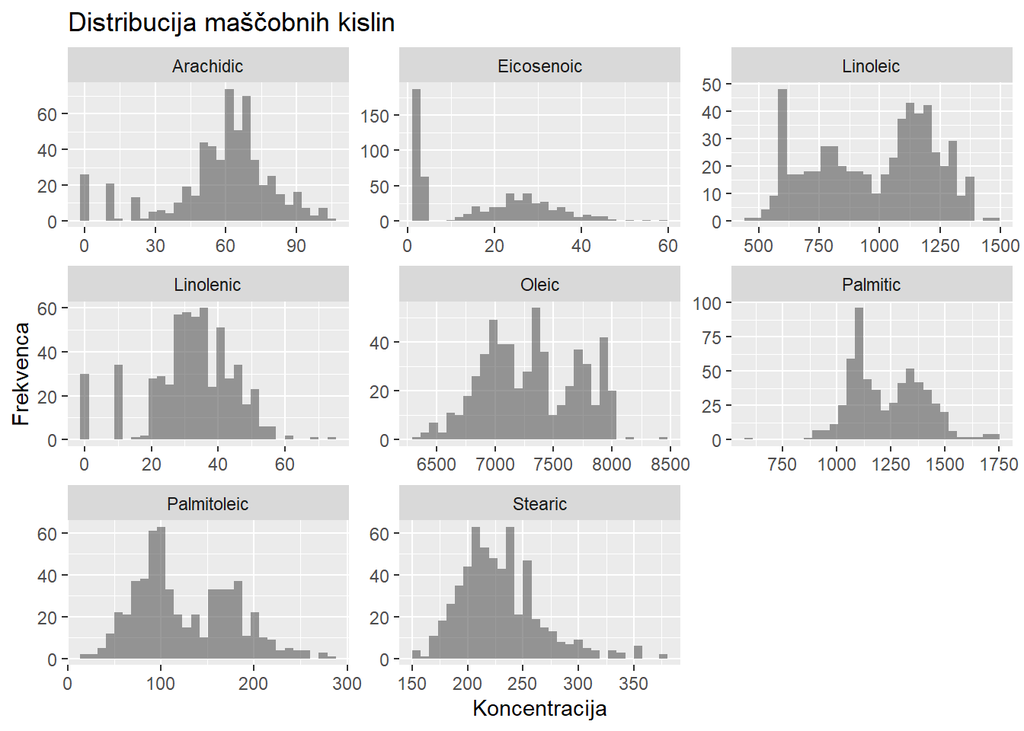

```r
ggplot(dataLong1,aes(x=koncentracija)) +
  geom_histogram(position="identity",alpha=0.6,bins=30) +
  facet_wrap(~mascobnaKislina,scales="free") +
  labs(title="Distribucija maščobnih kislin",
       x="Koncentracija",
       y="Frekvenca")
```

Iz histograma za palmitinsko kislino je razvidno, da porazdelitev ni normalna, saj kljub temu, da bi mediana lahko bila pribljižno enaka povprečju, večina vzorcev ni koncentriranih okoli nje.

Edina maščobna kislina, ki je pribljižno normalno porazdeljena, bi lahko bila stearična kislina.

### Naloga 2

Da bi preveril, kako se koncentracije izbranih maščobnih kislin razlikujejo po posameznih regijah, sem izračunal kvartile po regijah za vsako od kislin. To se lahko vizualno prikaže z okvirjem z ročaji.

**Koda**

```r
dataLong2 |>
  group_by(Label,mascobnaKislina) |>
  summarise(Q1=quantile(koncentracija,.25),
            Median=median(koncentracija),
            Q3=quantile(koncentracija,.75)) |>
  as_tibble() |>
  datatable(,options=list(pageLenght=10))
```

|  | Label | mascobnaKislina | Q1 | Median | Q3 |
| --- | --- | --- | --- | --- | --- |
| 1 | Calabria | Linoleic | 780 | 827 | 872.5 |
| 2 | Calabria | Oleic | 7233 | 7296 | 7379.25 |
| 3 | Calabria | Palmitic | 1260.75 | 1298.5 | 1352.25 |
| 4 | Coast-Sardinia | Linoleic | 1307 | 1330 | 1372 |
| 5 | Coast-Sardinia | Oleic | 7043 | 7080 | 7135 |
| 6 | Coast-Sardinia | Palmitic | 1120 | 1135 | 1160 |
| 7 | East-Liguria | Linoleic | 642.5 | 680 | 747.5 |
| 8 | East-Liguria | Oleic | 7672.5 | 7740 | 7820 |
| 9 | East-Liguria | Palmitic | 1112.5 | 1155 | 1180 |
| 10 | Inland-Sardinia | Linoleic | 1104 | 1120 | 1146 |

[output cut: 17 more lines]

**Koda**

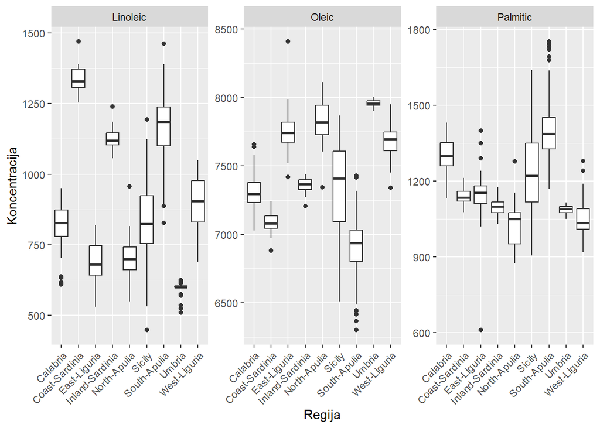

```r
dataLong2 |>
  ggplot(aes(x=Label,y=koncentracija)) +
  geom_boxplot() +
  facet_wrap(~mascobnaKislina,scales="free") +
  labs(x="Regija",
       y="Koncentracija") +
  theme(axis.text.x=element_text(angle=45,hjust=1))
```

Iz grafov je so raznidne razlike, ki med regijami, moramo pa paziti, da pravilno preberemo skale na y-osi, saj se skala za oleinsko kislino začne precej višje (pri 6500), med tem ko se drugi dve kislini konča pri 1500 in 1800.

### Naloga 3

Ali obstaja linearna povezava med dvema maščobnima kislinama, v primeru domače naloge sta to palmitinska in oleinska kislina, preverimo s Pearsonovim korelacijskim koeficientom, ki meri moč in smer linearne povezave.

**Koda**

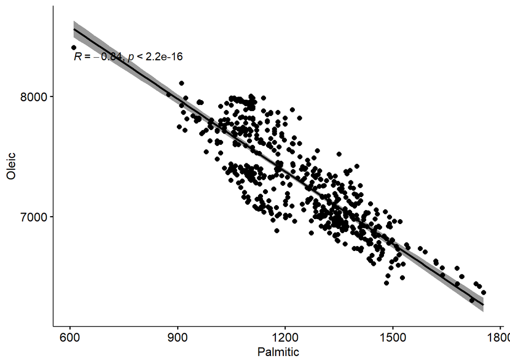

```r
ggscatter(data,x="Palmitic",y="Oleic",
         add="reg.line",
         conf.int=T,
         cor.coef=T,
         cor.method="pearson")
```

**Koda**

```r
corResult <- cor(data$Palmitic,data$Oleic)
print(paste("Pearsonov korelacijski koeficient:",corResult))
```

```
[1] "Pearsonov korelacijski koeficient: -0.837335352032492"
```

Iz grafa je razvidno, da sta kislini linearno povezani, namreč več kot je oleinske kisline, manj je palmitinske.

### Naloga 4

Ali so maščobne kisline normalno porazdeljene je s histogrami prikazano v prvi nalogi, sedaj pa je potrebno še preveriti. Z uporabo Q-Q grafikonov in trendne črte se preverja skladnost empiričnih kvatilov s teoretičnimi kvantili normalne porazdelitve.

**Koda**

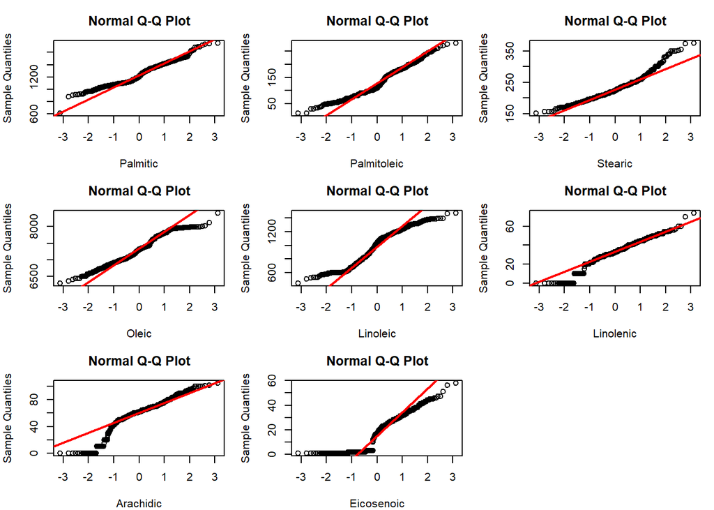

```r
par(mfrow=c(3,3),mar=c(4,4,3,1))

mascobneKisline<-names(data[c(5:12)])

for (mascobnaKislina in mascobneKisline) {
  qqnorm(data[[mascobnaKislina]],
         x=mascobnaKislina)
  qqline(data[[mascobnaKislina]],
         col="red",
         lwd=2)
}
```

Nobena od maščobnih kislin ni porazdeljena normalno.

### Naloga 5

Preučim lahko tudi ali obstajajo statistično značilne razlike v koncentraciji posameznih kislin glede na različne regije. Za to analizo sem uporabil analizo variance (ANOVA) za preverjanje razik med povprečji regij.

**Koda**

```r
anova_result <- aov(Linolenic~Label,data=data)
summary(anova_result)
```

```
             Df Sum Sq Mean Sq F value Pr(>F)
Label         8  60803    7600   121.5 <2e-16 ***
Residuals   563  35232      63
---
Signif. codes:  0 '***' 0.001 '**' 0.01 '*' 0.05 '.' 0.1 ' ' 1
```